# Act Report

This report provides the findings from WeRateDogs dataset. The questions that I made before analysis are as follows:

1. Does the tweet with higher rating get more retweets or favorites?
2. What time do the people upload WeRateDogs tweets?
3. Does the tweet with a picture type get a higher rating?

```python
# Import packages
import pandas as pd
import numpy as np
import os
import seaborn as sns
import matplotlib.pyplot as plt
%matplotlib inline
```

```python
# Import cleaned files
df = pd.read_csv('cleaned/twitter_archive_master.csv')
tweet_links = pd.read_csv('cleaned/twitter_links_master.csv')
tweet_urls = pd.read_csv('cleaned/twitter_urls_master.csv')
```

## 1. Does the tweet with higher rating get more retweets or favorites?

```python
# Get the 99% quantile of rating proportion and filter the outliers
rating_outlier_limit = (df.rating_numerator / df.rating_denominator).quantile(0.99)
retweet_outlier_limit = df.retweet_count.quantile(0.99)

df_filter1 = df[((df.rating_numerator / df.rating_denominator) < rating_outlier_limit) & (df.retweet_count < retweet_outlier_limit)]
```

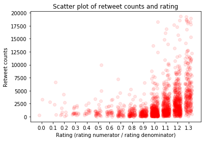

```python
# Scatter plot
sns.regplot(x=(df_filter1.rating_numerator / df_filter1.rating_denominator), y=df_filter1.retweet_count, x_jitter=0.03,
            scatter_kws={'alpha': 0.1}, fit_reg=False, color='red');
plt.xticks(np.arange(0, 1.4, 0.1));
plt.xlabel('Rating (rating numerator / rating denominator)');
plt.ylabel('Retweet counts');
plt.title('Scatter plot of retweet counts and rating');
```

> Rating and retweet count show a positive relationship, which means if a user uploads a WeRateDogs tweet with a good rating, it is more likely to be retweeted by other users. If you want your tweet more retweeted by other users, be generous on rating a dog :)

```python
# Get the 99% quantile of rating proportion and filter the outliers
favorite_outlier_limit = df.favorite_count.quantile(0.99)

df_filter2 = df[((df.rating_numerator / df.rating_denominator) < rating_outlier_limit) & (df.favorite_count < favorite_outlier_limit)]
```

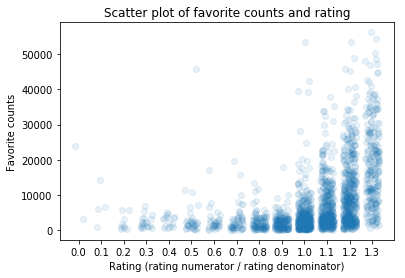

```python
# Scatter plot
a = sns.regplot(x=(df_filter2.rating_numerator / df_filter2.rating_denominator), y=df_filter2.favorite_count, x_jitter=0.03,
            scatter_kws={'alpha': 0.1}, fit_reg=False)
plt.xticks(np.arange(0, 1.4, 0.1))
plt.xlabel('Rating (rating numerator / rating denominator)')
plt.ylabel('Favorite counts');
plt.title('Scatter plot of favorite counts and rating');
```

> The relationship between rating and favorite count also shows a similar pattern with the scatter plot between rating and retweet count. In conclusion, highly rated WeRateDogs tweets get more social popularity in general.

## 2. What time do the people upload WeRateDogs tweets?

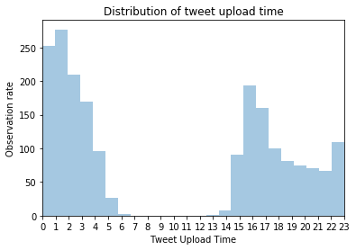

```python
# Change the data types of timestamps to datetime
df.timestamp = pd.to_datetime(df.timestamp)

# Histogram of tweet upload time
sns.distplot(df.timestamp.dt.hour, bins=24, kde=False);
plt.xlim(0,23);
plt.xticks(range(0, 24, 1));
plt.xlabel('Tweet Upload Time')
plt.ylabel('Observation rate');
plt.title('Distribution of tweet upload time');
```

## 3. Does the tweet with a picture type get a higher rating?

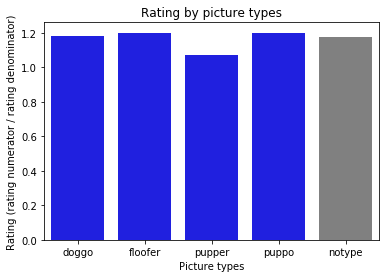

```python
# Change the missing values in picture type column to analaysis
df_for_figtype_analysis = df
df_for_figtype_analysis.picture_type = df_for_figtype_analysis.picture_type.fillna('notype')

# Average rating by type
avg_rating_by_type = df_for_figtype_analysis.groupby(df_for_figtype_analysis.picture_type).mean()[['rating_numerator', 'rating_denominator']]
avg_rating_by_type = avg_rating_by_type.rating_numerator / avg_rating_by_type.rating_denominator

# Bar graph of averge rating by picture type
sns.barplot(x=avg_rating_by_type.index, y=avg_rating_by_type, order=['doggo', 'floofer', 'pupper', 'puppo', 'notype'],
           palette=['blue', 'blue', 'blue', 'blue', 'gray']);
plt.xlabel('Picture types')
plt.ylabel('Rating (rating numerator / rating denominator)');
plt.title('Rating by picture types');
```

> The tweets without picture type and with picture type do not show a significant difference in rating. In terms of the tweets with picture types (not null), even though 'pupper' picture type has a relatively row average rating comparing to other types, it does not mean it has a practical meaning when we consider that the 'pupper' and 'puppo' have actually very similar meaning.